# School Infrastructure in São Paulo

Author

Vinicius Hiago e Silva Gerônimo

Published

June 8, 2025

#### The following map shows the distribution of a infrastructure quality index in São Paulo.

## School Infrastructure Data

School-level data was obtained from the **2024 School Census**, accessed via the **Base dos Dados** organization’s datalake. The analysis focuses on active schools with reported high school enrollment.

```r
# Set the billing ID and the municipality code
basedosdados::set_billing_id('vinicius-projetos-r')
mun_code <- '3550308'

# Query to download infrastructure data from the School Census
census_query = paste("
SELECT
  id_escola, esgoto_rede_publica, agua_potavel, energia_inexistente,
  banheiro_pne, biblioteca, cozinha, laboratorio_ciencias, laboratorio_informatica,
  quadra_esportes, sala_diretoria, sala_leitura, sala_atendimento_especial,
  equipamento_computador, equipamento_copiadora, equipamento_impressora,
  equipamento_tv, banda_larga
FROM `basedosdados.br_inep_censo_escolar.escola`
WHERE ano = 2024 AND id_municipio = '", mun_code,"' AND tipo_situacao_funcionamento = '1' AND etapa_ensino_medio = 1
", sep="")

census_base = as.data.frame(basedosdados::read_sql(
    query = gsub("\\s+", " ", census_query)))

for (col in c(2:dim(census_base)[2])){
  census_base[,col] = as.numeric(census_base[,col])
}
```

## Geolocation

School locations were determined by their latitude and longitude coordinates, sourced from Inep’s **Catálogo das Escolas** (School Catalog).

```r
school_geoloc <- readxl::read_xlsx("Coordenadas_escolas.xlsx")

final_base_raw <- left_join(
  x = census_base,
  y = school_geoloc %>% select(c(Código, Escola, Latitude, Longitude)),
  by = c('id_escola' = 'Código')) %>%
  filter(!is.na(Latitude), !is.na(Longitude))
```

## Index

A composite infrastructure index was built for each school using a **2-Parameter Logistic Item Response Theory** (IRT) model. The final scores were then standardized to a scale with a mean of 50 and a standard deviation of 10. A higher index value corresponds to a better school infraestructure quality. The index incorporates

> esgoto_rede_publica, agua_potavel, energia_inexistente, banheiro_pne, biblioteca, cozinha, laboratorio_ciencias, laboratorio_informatica, quadra_esportes, sala_diretoria, sala_leitura, sala_atendimento_especial, equipamento_computador, equipamento_copiadora, equipamento_impressora, equipamento_tv, banda_larga.

```r
irt = mirt(final_base_raw %>%
             select(-c(id_escola, Escola, Latitude, Longitude)) %>%
             select(where(~ n_distinct(.)>1)),
     model = 1,
     itemtype = '2PL',
     verbose = F)

raw_index <- fscores(irt, method = 'EAP') * -1

# Standardized index
final_index_df <- as.data.frame(raw_index) %>%
  mutate(
    final_index = 50 + (10 * (F1 - mean(F1)) / sd(F1))
  )


final_base_sf <- final_base_raw %>%
  mutate(infra_index = final_index_df$final_index) %>%
  st_as_sf(
    coords = c("Longitude", "Latitude"),
    crs = 4674 # SIRGAS 2000
  )
```

## Geographic Boundaries

Official geographic boundaries for municipality and **IBGE’s Weighting Areas** were sourced using the R package `geobr`. The value shown for each region is the mean of the schools’ index located whitin that Weighting Area.

```r
estate = lookup_muni(code_muni = as.character(mun_code))$name_state
muni = lookup_muni(code_muni = as.character(mun_code))$name_muni

# Get municipalitie's boundaries
muni_boundary = read_municipality(code_muni = mun_code)

# Get weighting area's boundaries
weighting_areas = read_weighting_area() %>%
  filter(code_muni == mun_code)

# Join tables
schools_in_areas <- st_join(final_base_sf, weighting_areas, join = st_intersects)

# Calculate the mean index of each weighting area
areas_with_index <- left_join(
  weighting_areas,
  schools_in_areas %>%
    st_drop_geometry() %>%
    group_by(code_weighting) %>%
    summarise(
      mean_area = mean(infra_index, na.rm = TRUE),
      n_schools = n()
    ) %>%
    ungroup(),
  by = 'code_weighting'
)
```

## Maps

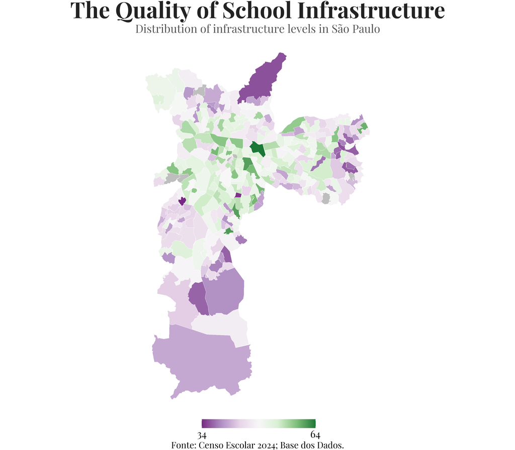

```r
min_val <- min(areas_with_index$mean_area, na.rm = TRUE)
max_val <- max(areas_with_index$mean_area, na.rm = TRUE)

ggplot() +
  geom_sf(data = areas_with_index, aes(fill=mean_area), color = "white", linewidth = 0.2) +
  scale_fill_distiller(
    name = "",
    palette = "PRGn",
    direction = 1,
    na.value = "grey",
    limits = c(min_val, max_val),
    breaks = c(min_val, max_val),
    labels = label_number(accuracy = 1)) +
  geom_sf(data = muni_boundary, fill = NA, color = "white", linewidth = 0.5) +
  labs(
    title = "The Quality of School Infrastructure",
    subtitle = paste("Distribution of infrastructure levels in", muni),
    caption = "Fonte: Censo Escolar 2024; Base dos Dados."
  ) +
  theme_void() +
  theme(
    plot.title = element_text(family = "pf", size = 100, face = "bold", color = "#222222", hjust = 0.5),
    plot.subtitle = element_text(family = "pf", size = 50, color = "#555555", hjust = 0.5),
    legend.text = element_text(family = "pf", size = 45),
    plot.caption = element_text(family = "pf", size = 40, hjust = 0.5),
    legend.position = 'bottom',
    legend.key.width = unit(1.8, "cm"),
    legend.key.size= unit(0.7, "cm")
  )
```